# Credit Card Default

### Predict with the Random Forest Classifer

```r
rf_prediction <- predict(rf_classifer_2, test)

table(observed = test$default.payment.next.month, predicted = rf_prediction)
```

```
##         predicted
## observed    0    1
##        0 4450  260
##        1  861  429
```

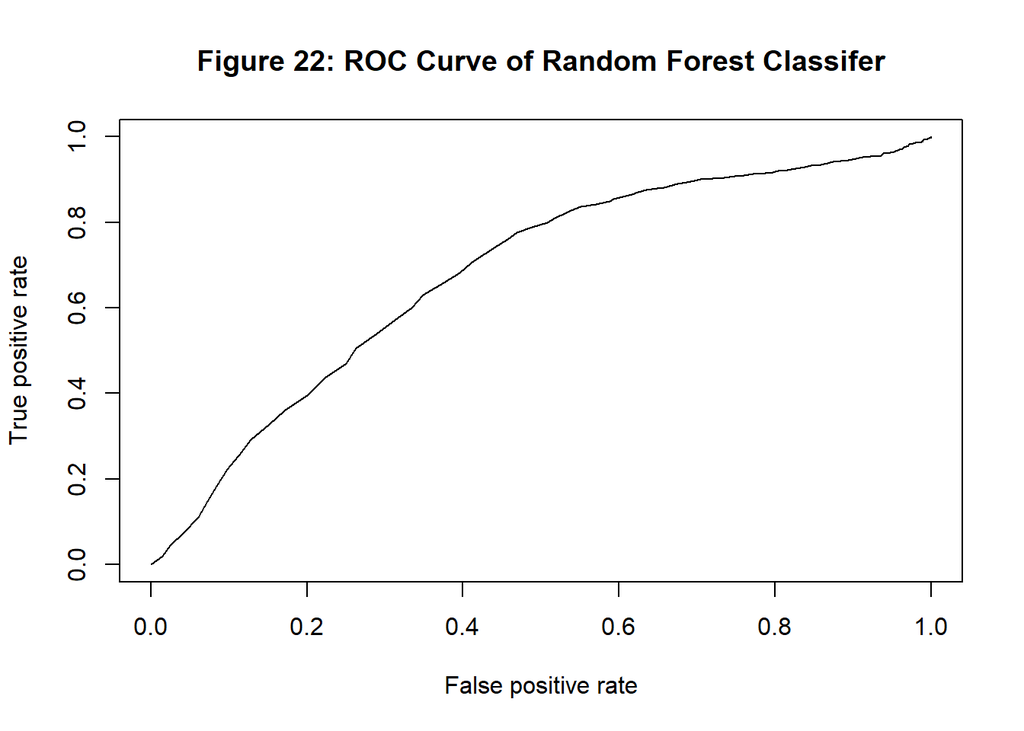

```r
rf_prediction_prob <-  predict(rf_classifer_2, test, type = 'prob')

true_value <- ifelse(test$default.payment.next.month == rf_prediction, 1, 0)

pred <- prediction(rf_prediction_prob[, 1], true_value)

perf <- performance(pred, 'tpr', 'fpr')

plot(perf, main = 'Figure 22: ROC Curve of Random Forest Classifer')
```

```r
auc.perf <- performance(pred, measure = 'auc')

accuracy.rf <- as.numeric(auc.perf@y.values)

print(auc.perf@y.values)
```

```
## [[1]]
## [1] 0.6794891
```

## GBM Model

Gradient boosting is a machine learning technique for regression and classification problems, which produces a prediction model in the form of an ensemble of weak prediction models, typically decision trees. It builds the model in an iterative fashion like other boosting methods do, and it generalizes them by allowing optimization of an arbitrary differentiate loss function.

https://koalaverse.github.io/machine-learning-in-R/gradient-boosting-machines.html

```r
# Train model with preprocessing & repeated cv
model_gbm <- caret::train(default.payment.next.month ~ .,
                          data = train,
                          method = "gbm",
                          preProcess = c("scale", "center"),
                          trControl = trainControl(method = "repeatedcv",
                                                  number = 5,
                                                  repeats = 3,
                                                  verboseIter = FALSE),
                          verbose = 0, na.action=na.exclude)
model_gbm
```

```
## Stochastic Gradient Boosting
##
## 24000 samples
##    26 predictor
##     2 classes: '0', '1'
##
## Pre-processing: scaled (75), centered (75)
## Resampling: Cross-Validated (5 fold, repeated 3 times)
## Summary of sample sizes: 19200, 19200, 19200, 19200, 19200, 19200, ...
## Resampling results across tuning parameters:
##
##   interaction.depth  n.trees  Accuracy   Kappa
##   1                   50      0.7885416  0.1069144
##   1                  100      0.8001110  0.2194949
##   1                  150      0.8037360  0.2598349
##   2                   50      0.8082637  0.2895385
##   2                  100      0.8125554  0.3289352
##   2                  150      0.8140138  0.3418807
##   3                   50      0.8119443  0.3248487
##   3                  100      0.8147776  0.3480917
##   3                  150      0.8157499  0.3541965
##
## Tuning parameter 'shrinkage' was held constant at a value of 0.1
##
## Tuning parameter 'n.minobsinnode' was held constant at a value of 10
## Accuracy was used to select the optimal model using the largest value.
## The final values used for the model were n.trees = 150, interaction.depth =
##  3, shrinkage = 0.1 and n.minobsinnode = 10.
```

```r
# Test GBM Model against Test Data
pred.int <- predict(model_gbm, test, interval = "prediction")#; pred.int
gbm_data_frame <- cbind(test$default.payment.next.month, pred.int)#; gbm_data_frame
gbm_data_frame = as.data.frame(gbm_data_frame)#; gbm_data_frame


gbm.correct <- rep(0, nrow(gbm_data_frame))
for (i in 1:nrow(gbm_data_frame)) {
  gbm.correct[i] <- ifelse(gbm_data_frame$V1[i] == gbm_data_frame$pred.int[i], 1, 0)
}

accuracy.gbm <- sum(gbm.correct)/length(gbm.correct)
```

## Model Comparison

```r
# TABLE 2
model.comparison <- data.frame(

  Model = c('Logistic Model 2',
            'Logistic Model Payments',
            'Logistic Model Demographics',
            'KNN Model',
            'Random Forest',
            'GMB Model'
            ),
  Accuracy = c(confusionMatrix(test.results$logistic.model2.prediction, test.results$default.payment.next.month)$overall['Accuracy'],
               confusionMatrix(test.results$logistic.modelpayments.prediction, test.results$default.payment.next.month)$overall['Accuracy'],
               confusionMatrix(test.results$logistic.modeldemographics.prediction, test.results$default.payment.next.month)$overall['Accuracy'],
               round(accuracy.knn, 3),
               round(accuracy.rf,3),
               round(accuracy.gbm, 3)
               )

)


model.comparison
```

```
##                         Model  Accuracy
## 1            Logistic Model 2 0.7078333
## 2     Logistic Model Payments 0.7395000
## 3 Logistic Model Demographics 0.4808333
## 4                   KNN Model 0.9350000
## 5               Random Forest 0.6790000
## 6                   GMB Model 0.8190000
```

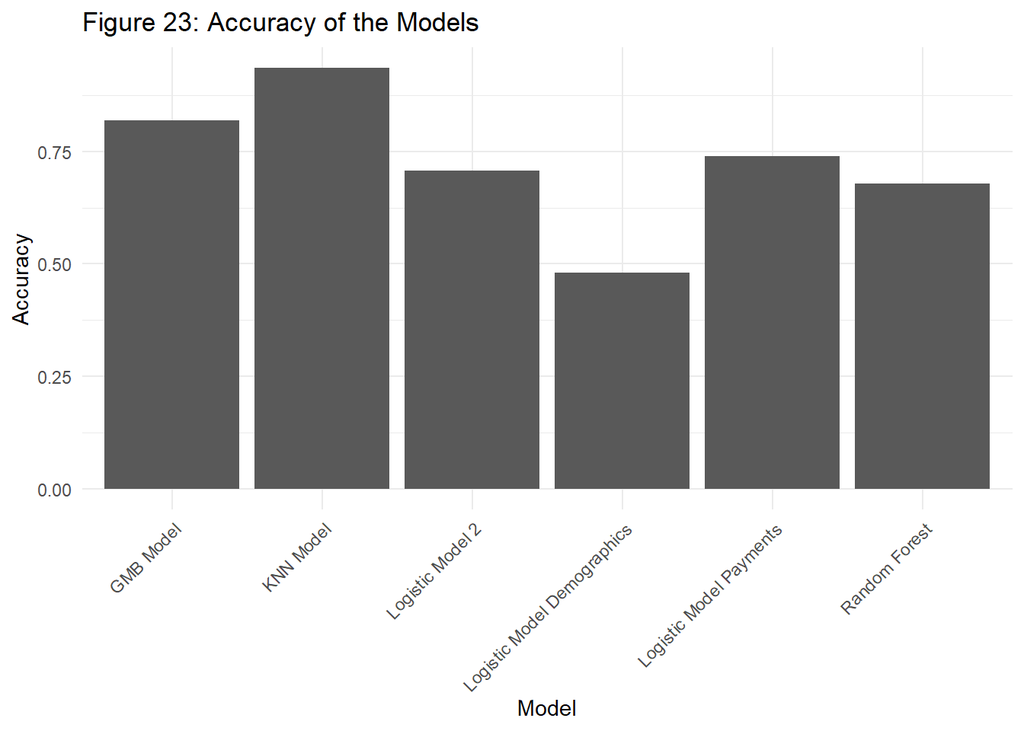

```r
model.comparison %>%
  arrange(Accuracy) %>%
  ggplot(aes(x = Model, y = Accuracy)) +
  geom_col() +
  ggtitle('Figure 23: Accuracy of the Models') +
  theme_minimal() +
  theme(
    axis.text.x = element_text(angle = 45, hjust = 1)
  )
```

# Conclusion

In this section we reviewed the effectiveness of utilizing demographic variables (collected prior to credit card issument) to determine if they are a viable method for predicting default payment among our clients. In short - they are not. While the demographic variables are significant predictors of default. However, our model that solely relies on demographic variables to make predicts has a low accuracy. Meaning, that our demographic variables as a base are not helpful in determining who might default. With this in mind, we’ll pivot here to focus on all known variables to build our model (either existing, engineered, or inputted in to our machine learning systems)

We inputted our data into three (3) machine learning classification models: * K-Nearest Neighbors * Random Forest * Gradient Boosting

Recommendations: * When issuing credits, ignore demographic data as it is poor method for predicting default payment * Our strongest predictors of default tend to fall within the payment category, specifically ‘Pay_0’ and ‘Pay_Avg.’ * With this in mind, we would recommend that your Bank should focus its efforts on early payment reminders, * In addition to early reminders, we would also push for regularly on-time payment incentives - ranging from local, gift cards to discounted services. * Implement optional spending controls after Pay_6 for customers that want to manage their debt and climb back to Pay_0 status.